# Debjit_Ray_12010066_FA_Assignment

Debjit Ray

10/05/2021

### *Consider the data set SouvenirSales.xls (1995 Jan -2001 Dec) that gives the monthly sales of souvenir at a shop in New York. Back in 2001, an analyst was appointed to forecast sales for the next 12 months (Year 2002). The analyst portioned the data by keeping the last 12 months of data (year 2001) as validation set, and the remaining data as training set.*

```r
library(readxl)
setwd("C:/Debjit/ISB/05_Term-4/FA/Indiv. Assignment/")
salesData <- read_excel("SouvenirSales.xlsx")
str(salesData)
```

```
## tibble [84 x 2] (S3: tbl_df/tbl/data.frame)
##  $ Date : POSIXct[1:84], format: "1995-01-01" "1995-02-01" ...
##  $ Sales: num [1:84] 1665 2398 2841 3547 3753 ...
```

```r
salesData <- ts(data = salesData$Sales, start = c(1995,1), freq=12)
trainSet <- window(salesData, end= c(2000,12))
testSet <- window(salesData, start= c(2001,1))
```

### *a. Plot the time series of the original data. Which time series components appear from the plot.*

```r
library("dygraphs")
dygraph(salesData, main = "Souvenoir sales") %>% dyRangeSelector()
```

[interactive chart not shown]

#### From the graph, we can notice the following:

++ There is a *slight upper trend* in Sales across the years.  
++ Every year there is a *peak in sales in the month of March and December*.  
++ The seasonality for the month of December seems to be Multiplicative in nature.

```r
library(forecast)
```

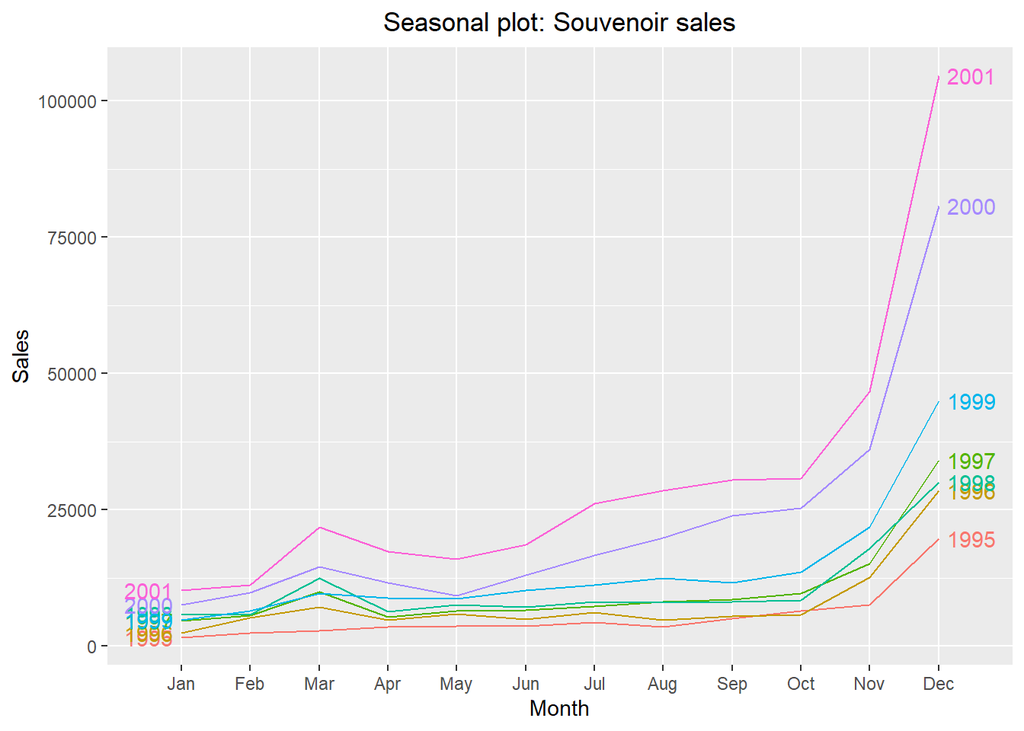

```r
library(ggplot2)
ggseasonplot(salesData, year.labels=TRUE, year.labels.left=TRUE) +
  ylab("Sales") +
  ggtitle("Seasonal plot: Souvenoir sales") +  theme(plot.title = element_text(hjust = 0.5))
```

#### The seasonal plot confirms our earlier observation regarding peaks in December and March.

```r
library(zoo)
library(ggpubr)
```

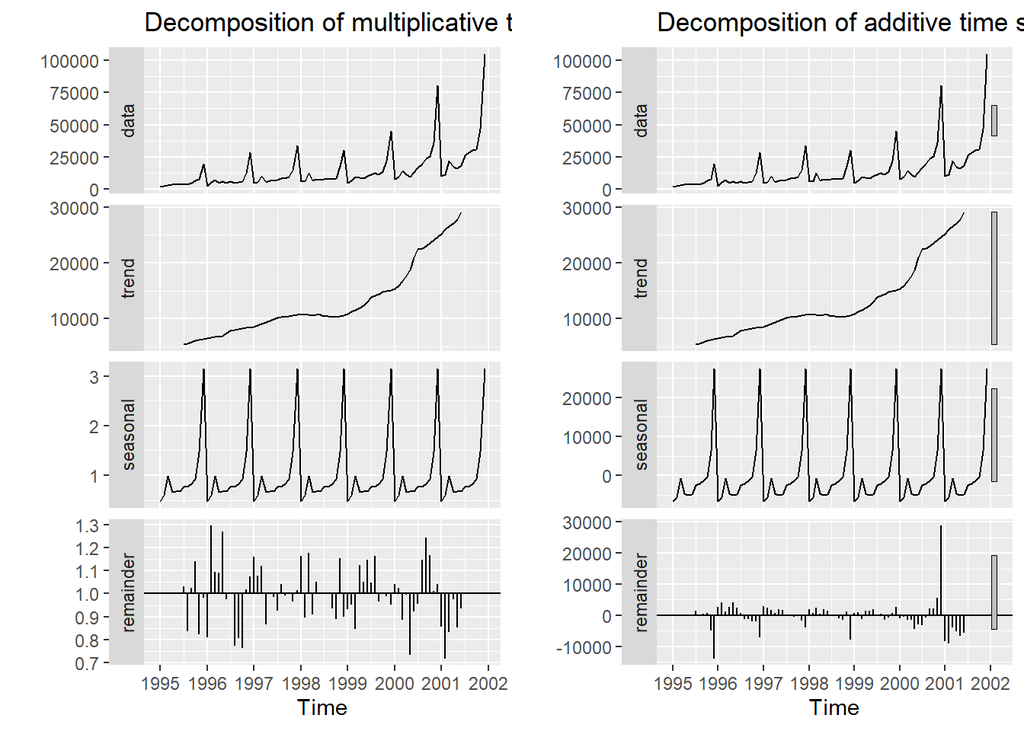

```r
multPlot <- autoplot(decompose(salesData, type = "multiplicative"))
addplot <- autoplot(decompose(salesData, type = "additive"))
ggarrange(multPlot, addplot)
```

### *b. Fit a linear trend model with additive seasonality (Model A) and exponential trend model with multiplicative seasonality (Model B). Consider January as the reference group for each model. Produce the regression coefficients and the validation set errors. Remember to fit only the training period.*

```r
# Define the model with linear trend and additive seasonality
modelA <- tslm(trainSet ~ trend +  season)
# Check the model summary for the regression coefficients
summary(modelA)
```

```
##
## Call:
## tslm(formula = trainSet ~ trend + season)
##
## Residuals:
##    Min     1Q Median     3Q    Max
## -12592  -2359   -411   1940  33651
##
## Coefficients:
##             Estimate Std. Error t value Pr(>|t|)
## (Intercept) -3065.55    2640.26  -1.161  0.25029
## trend         245.36      34.08   7.199 1.24e-09 ***
## season2      1119.38    3422.06   0.327  0.74474
## season3      4408.84    3422.56   1.288  0.20272
## season4      1462.57    3423.41   0.427  0.67077
## season5      1446.19    3424.60   0.422  0.67434
## season6      1867.98    3426.13   0.545  0.58766
## season7      2988.56    3427.99   0.872  0.38684
## season8      3227.58    3430.19   0.941  0.35058
## season9      3955.56    3432.73   1.152  0.25384
## season10     4821.66    3435.61   1.403  0.16573
## season11    11524.64    3438.82   3.351  0.00141 **
## season12    32469.55    3442.36   9.432 2.19e-13 ***
## ---
## Signif. codes:  0 '***' 0.001 '**' 0.01 '*' 0.05 '.' 0.1 ' ' 1
##
## Residual standard error: 5927 on 59 degrees of freedom
## Multiple R-squared:  0.7903, Adjusted R-squared:  0.7476
## F-statistic: 18.53 on 12 and 59 DF,  p-value: 9.435e-16
```

```r
# Predict for the validation time period using this model
modelA_Forecast <- forecast(modelA, h=length(testSet), level = 0)
```

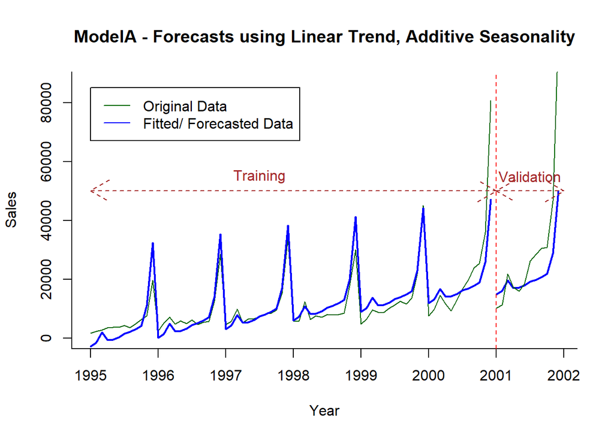

```r
# Plot the graphs to help understand how close our model is to the actual values.
# Plot the original training data (actual Sales) for the training period and the model forecasted data for the validation period
plot(modelA_Forecast, ylab = "Sales", xlab = "Year", bty = "l", col = "darkgreen", ylim=c(0, 87000),
     main = "ModelA - Forecasts using Linear Trend, Additive Seasonality")
# Plot the model fitted data for the training period
lines(modelA$fitted, lwd = 2, col = "blue")
# Plot the actual sales data for the validation period
lines(testSet, col = "darkgreen")
# Add legend
legend(1995,85000, legend=c("Original Data", "Fitted/ Forecasted Data"),  col=c("darkgreen", "blue"), lty=1:1, cex=1)
# Add markers to distingush the training and validation period on the graph
abline(v=c(2001), col = "red", lty = 2)
arrows(1995,50000,2001,50000,col="brown", code=3, lty = 2)
arrows(2001,50000,2002,50000,col="brown", code=3, lty = 2)
text(1997.5,55000,"Training",col="brown")
text(2001.5,55000,"Validation",col="brown")
```

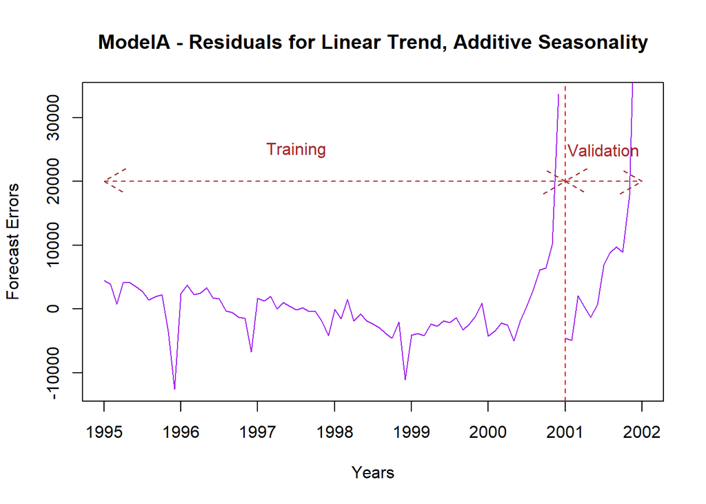

```r
# Plot the residual graph for the training period
plot(modelA$residuals, ylab = "Forecast Errors", xlab = "Years", xlim = c(1995, 2002), col = "purple",
     main = "ModelA - Residuals for Linear Trend, Additive Seasonality")
# Plot the residuals/ errors for the validation period
lines(testSet - modelA_Forecast$mean, col = "purple")
# Add markers to distingush the training and validation period on the graph
abline(v=c(2001), col = "red", lty = 2)
arrows(1995,20000,2001,20000,col="brown", code=3, lty = 2)
arrows(2001,20000,2002,20000,col="brown", code=3, lty = 2)
text(1997.5,25000,"Training",col="brown")
text(2001.5,25000,"Validation",col="brown")
```

```r
# Define the model with linear trend and additive seasonality
modelB <- tslm(trainSet ~ trend + season, lambda = 0)
# Check the model summary for the regression coefficients
summary(modelB)
```

```
##
## Call:
## tslm(formula = trainSet ~ trend + season, lambda = 0)
##
## Residuals:
##     Min      1Q  Median      3Q     Max
## -0.4529 -0.1163  0.0001  0.1005  0.3438
##
## Coefficients:
##             Estimate Std. Error t value Pr(>|t|)
## (Intercept) 7.646363   0.084120  90.898  < 2e-16 ***
## trend       0.021120   0.001086  19.449  < 2e-16 ***
## season2     0.282015   0.109028   2.587 0.012178 *
## season3     0.694998   0.109044   6.374 3.08e-08 ***
## season4     0.373873   0.109071   3.428 0.001115 **
## season5     0.421710   0.109109   3.865 0.000279 ***
## season6     0.447046   0.109158   4.095 0.000130 ***
## season7     0.583380   0.109217   5.341 1.55e-06 ***
## season8     0.546897   0.109287   5.004 5.37e-06 ***
## season9     0.635565   0.109368   5.811 2.65e-07 ***
## season10    0.729490   0.109460   6.664 9.98e-09 ***
## season11    1.200954   0.109562  10.961 7.38e-16 ***
## season12    1.952202   0.109675  17.800  < 2e-16 ***
## ---
## Signif. codes:  0 '***' 0.001 '**' 0.01 '*' 0.05 '.' 0.1 ' ' 1
##
## Residual standard error: 0.1888 on 59 degrees of freedom
## Multiple R-squared:  0.9424, Adjusted R-squared:  0.9306
## F-statistic:  80.4 on 12 and 59 DF,  p-value: < 2.2e-16
```

```r
# Predict for the validation time period using this model
modelB_Forecast <- forecast(modelB, h=length(testSet), level = 0)
```

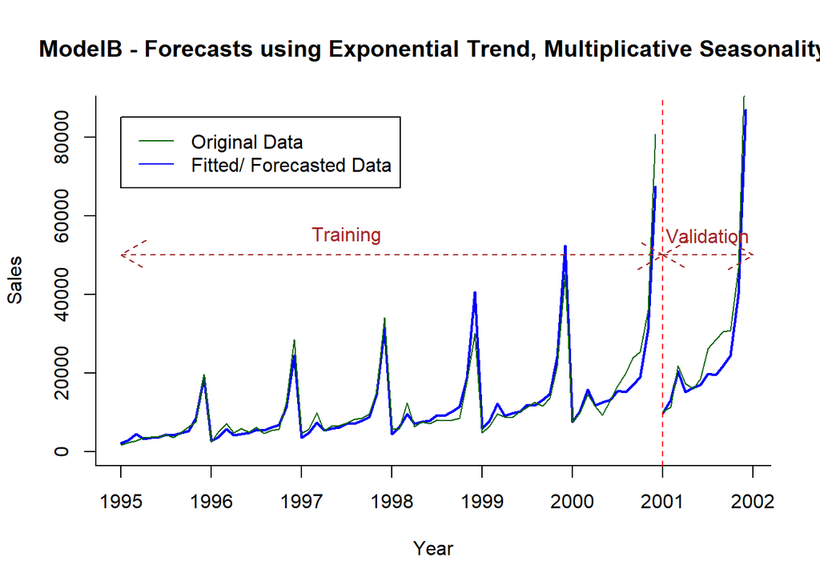

```r
# Plot the graphs to help understand how close our model is to the actual values.
# Plot the original training data (actual Sales) for the training period and the model forecasted data for the validation period
plot(modelB_Forecast, ylab = "Sales", xlab = "Year", bty = "l", col = "darkgreen", ylim=c(0, 87000),
     main = "ModelB - Forecasts using Exponential Trend, Multiplicative Seasonality")
# Plot the model fitted data for the training period
lines(modelB$fitted, lwd = 2, col = "blue")
# Plot the actual sales data for the validation and training period
lines(testSet, col = "darkgreen")
lines(trainSet, col = "darkgreen")
# Add legend
legend(1995,85000, legend=c("Original Data", "Fitted/ Forecasted Data"),  col=c("darkgreen", "blue"), lty=1:1, cex=1)
# Add markers to distingush the training and validation period on the graph
abline(v=c(2001), col = "red", lty = 2)
arrows(1995,50000,2001,50000,col="brown", code=3, lty = 2)
arrows(2001,50000,2002,50000,col="brown", code=3, lty = 2)
text(1997.5,55000,"Training",col="brown")
text(2001.5,55000,"Validation",col="brown")
```

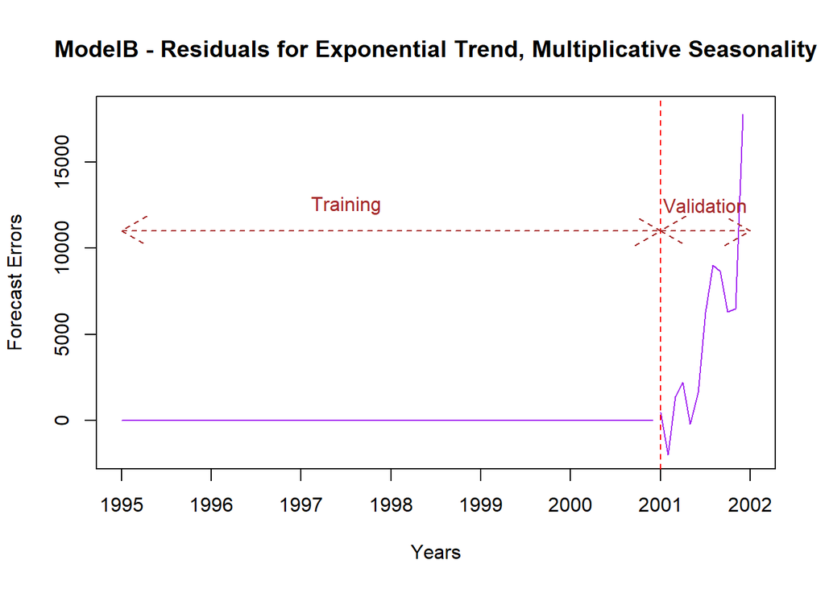

```r
# Plot the residual graph for the training period
plot(modelB$residuals, ylab = "Forecast Errors", xlab = "Years", xlim = c(1995, 2002), col = "purple", ylim = c(-2000, 18000),
     main = "ModelB - Residuals for Exponential Trend, Multiplicative Seasonality")
# Plot the residuals/ errors for the validation period
lines(testSet - modelB_Forecast$mean, col = "purple")
# Add markers to distingush the training and validation period on the graph
abline(v=c(2001), col = "red", lty = 2)
abline(v=c(2001), col = "red", lty = 2)
arrows(1995,11000,2001,11000,col="brown", code=3, lty = 2)
arrows(2001,11000,2002,11000,col="brown", code=3, lty = 2)
text(1997.5,12500,"Training",col="brown")
text(2001.5,12500,"Validation",col="brown")
```

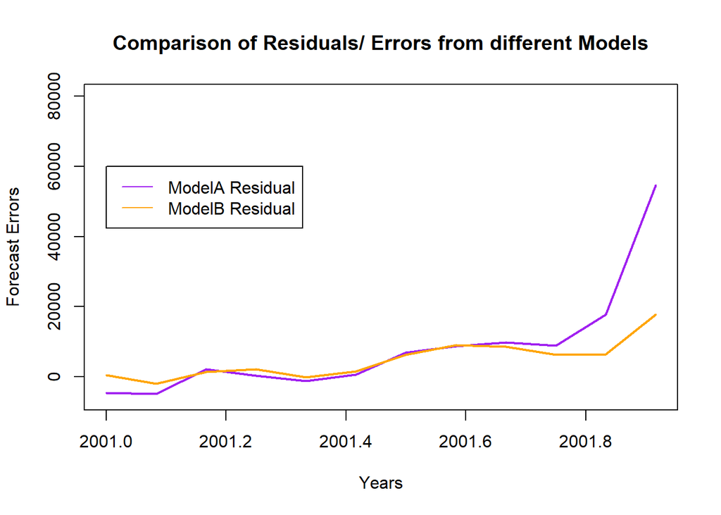

```r
plot(testSet - modelA_Forecast$mean, ylab = "Forecast Errors", xlab = "Years", col = "purple", ylim = c(-6000, 80000), lwd = 2,
     main = "Comparison of Residuals/ Errors from different Models")
lines((testSet - modelB_Forecast$mean), col = 'orange', lwd = 2)
# Add legend
legend(2001,60000, legend=c("ModelA Residual", "ModelB Residual"),  col=c("purple", "orange"), lty=1:1, cex=1)
```

#### Considering a Regression model with Exponential Trend and Multiplicative Seasonality can also be built using a log transformed series, we will explore to see if the model built is similar.

```r
# Define the model with linear trend and additive seasonality
modelB_1 <- tslm(log(trainSet) ~ trend + season)
# Check the model summary for the regression coefficients
summary(modelB_1)
```

```
##
## Call:
## tslm(formula = log(trainSet) ~ trend + season)
##
## Residuals:
##     Min      1Q  Median      3Q     Max
## -0.4529 -0.1163  0.0001  0.1005  0.3438
##
## Coefficients:
##             Estimate Std. Error t value Pr(>|t|)
## (Intercept) 7.646363   0.084120  90.898  < 2e-16 ***
## trend       0.021120   0.001086  19.449  < 2e-16 ***
## season2     0.282015   0.109028   2.587 0.012178 *
## season3     0.694998   0.109044   6.374 3.08e-08 ***
## season4     0.373873   0.109071   3.428 0.001115 **
## season5     0.421710   0.109109   3.865 0.000279 ***
## season6     0.447046   0.109158   4.095 0.000130 ***
## season7     0.583380   0.109217   5.341 1.55e-06 ***
## season8     0.546897   0.109287   5.004 5.37e-06 ***
## season9     0.635565   0.109368   5.811 2.65e-07 ***
## season10    0.729490   0.109460   6.664 9.98e-09 ***
## season11    1.200954   0.109562  10.961 7.38e-16 ***
## season12    1.952202   0.109675  17.800  < 2e-16 ***
## ---
## Signif. codes:  0 '***' 0.001 '**' 0.01 '*' 0.05 '.' 0.1 ' ' 1
##
## Residual standard error: 0.1888 on 59 degrees of freedom
## Multiple R-squared:  0.9424, Adjusted R-squared:  0.9306
## F-statistic:  80.4 on 12 and 59 DF,  p-value: < 2.2e-16
```

```r
# Predict for the validation time period using this model
modelB_1_Forecast <- forecast(modelB_1, h=length(testSet), level = 0)
```

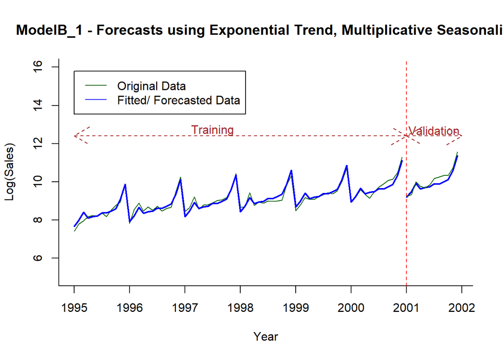

```r
# Plot the graphs to help understand how close our model is to the actual values.
# Plot the original training data (actual Sales) for the training period and the model forecasted data for the validation period
plot(modelB_1_Forecast, ylab = "Log(Sales)", xlab = "Year", bty = "l", col = "darkgreen",ylim=c(5,16),
     main = "ModelB_1 - Forecasts using Exponential Trend, Multiplicative Seasonality")
# Plot the model fitted data for the training period
lines(modelB_1$fitted, lwd = 2, col = "blue")
# Plot the actual sales data for the validation period
lines(log(testSet), col = "darkgreen")
# Add legend
legend(1995,15.8, legend=c("Original Data", "Fitted/ Forecasted Data"),  col=c("darkgreen", "blue"), lty=1:1, cex=1)
# Add markers to distingush the training and validation period on the graph
abline(v=c(2001), col = "red", lty = 2)
arrows(1995,12.4,2001,12.4,col="brown", code=3, lty = 2)
arrows(2001,12.4,2002,12.4,col="brown", code=3, lty = 2)
text(1997.5,12.7,"Training",col="brown")
text(2001.5,12.7,"Validation",col="brown")
```

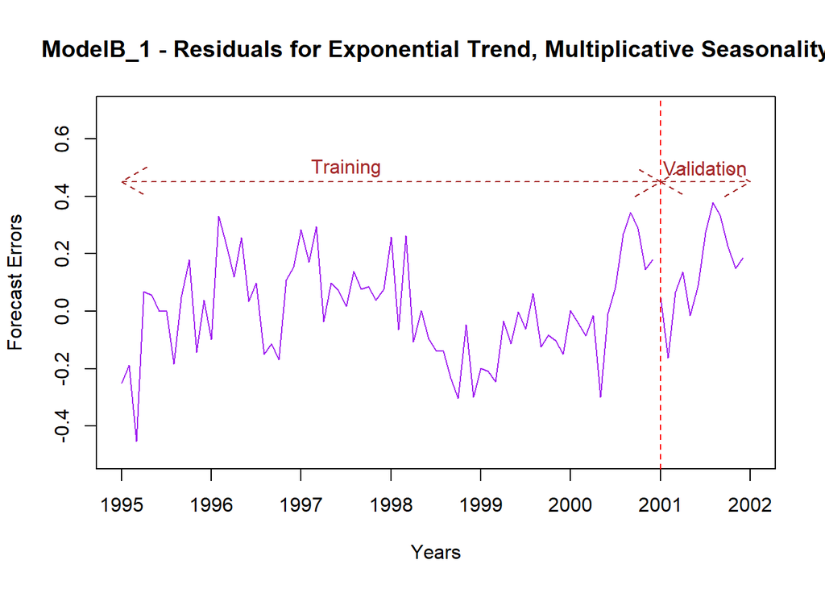

```r
# Plot the residual graph for the training period
plot(modelB_1$residuals, ylab = "Forecast Errors", xlab = "Years", xlim = c(1995, 2002), col = "purple", ylim = c(-0.5, 0.7),
     main = "ModelB_1 - Residuals for Exponential Trend, Multiplicative Seasonality")
# Plot the residuals/ errors for the validation period
lines(log(testSet) - modelB_1_Forecast$mean, col = "purple")
# Add markers to distingush the training and validation period on the graph
abline(v=c(2001), col = "red", lty = 2)
arrows(1995,0.45,2001,0.45,col="brown", code=3, lty = 2)
arrows(2001,0.45,2002,0.45,col="brown", code=3, lty = 2)
text(1997.5,0.5,"Training",col="brown")
text(2001.5,0.5,"Validation",col="brown")
```

### *c. Which model is the best model considering RMSE as the metric? Could you have understood this from the line chart? Explain. Produce the plot showing the forecasts from both models along with actual data. In a separate plot, present the residuals from both models (consider only the validation set residuals).*

```r
print ("Model A's Metrics")
```

```
## [1] "Model A's Metrics"
```

```r
accuracy(modelA_Forecast, testSet)
```

```
##                         ME      RMSE       MAE       MPE     MAPE     MASE
## Training set -5.684342e-14  5365.199  3205.089  6.967778 36.75088 0.855877
## Test set      8.251513e+03 17451.547 10055.276 10.533974 26.66568 2.685130
##                   ACF1 Theil's U
## Training set 0.4048039        NA
## Test set     0.3206228 0.9075924
```

```r
print ("Model B's Metrics")
```

```
## [1] "Model B's Metrics"
```

```r
accuracy(modelB_Forecast, testSet)
```

```
##                    ME     RMSE      MAE      MPE    MAPE MASE      ACF1
## Training set      Inf      Inf      Inf      NaN     NaN  NaN        NA
## Test set     4824.494 7101.444 5191.669 12.35943 15.5191  NaN 0.4245018
##              Theil's U
## Training set        NA
## Test set     0.4610253
```

#### Thus based on RMSE, the Exponential Trend with Multiplicative Seasonality model is performing much better than the Linear Trend with Additive Seasonality model.

#### Even though our hunch regarding the Seasonality being multiplicative seems to be true, our hunch related to Trend seems to be incorrect. From the original line chart of the Sales data this was difficult to guess, as the trend of sales data for months other than December seems to be increasing gradually.

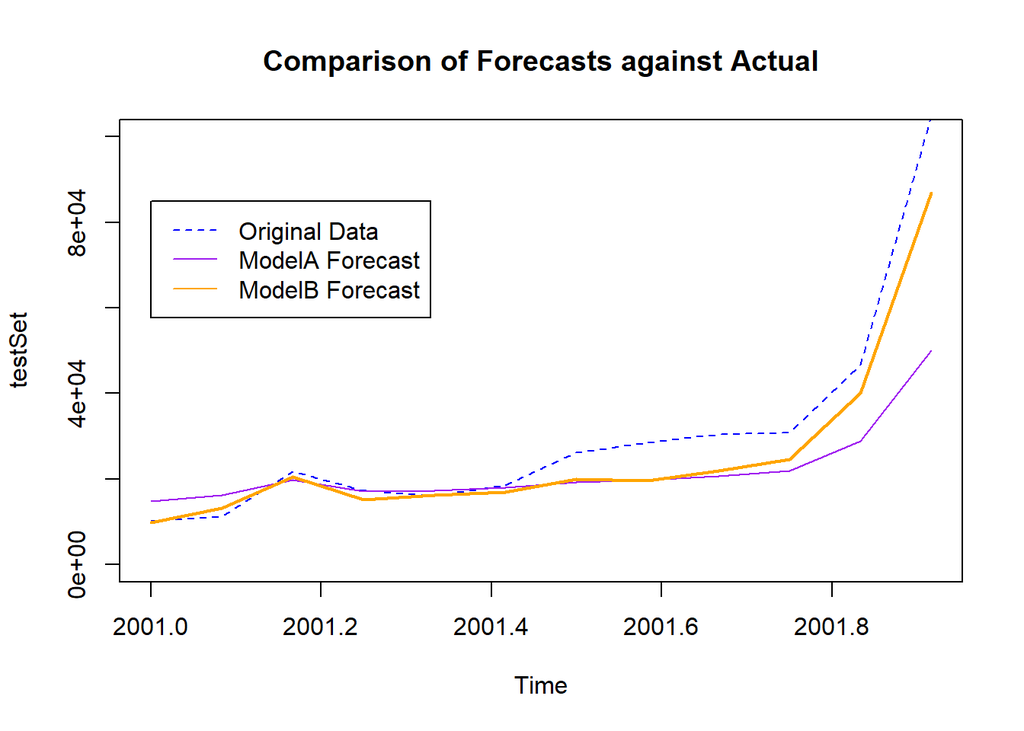

```r
plot(testSet, col = 'blue', lty = 2, ylim=c(0, 100000), main = "Comparison of Forecasts against Actual")
lines(modelA_Forecast$mean, col = 'purple')
lines(modelB_Forecast$mean, col = 'orange', lwd = 2)
# Add legend
legend(2001,85000, legend=c("Original Data", "ModelA Forecast", "ModelB Forecast"),  col=c( "blue", "purple", "orange"), lty=c(2,1,1), cex=1)
```

### *d. Examine the additive model. Which month has the highest average sales during the year. What does the estimated trend coefficient in the model A mean?*

#### The additive model based on the traning data is as below:

```
 $Y_{t} = -3065.55 + 245.36*t + 1119.38*season2 + 4408.84*season3 + 1462.57*season4 + 1446.19*season5 + 1867.98*season6 + 2988.56*season7 + 3227.58*season8 + 3955.56*season9 + 4821.66*season10 + 11524.64*season11 + 32469.55*season12$
```

#### To determine the month with the highest average sales during a year, we can directly review the coefficients in the regression equation for each month. In our model, we see that January has been taken as reference and for each of the other months; the coefficients have been calculated. These coefficients signify the relative increase in sales in the corresponding month compared to January. In our model, the highest coefficient is for season12 i.e. December. Hence, we can deduce December beng the month with the highest average sales during the year. Our deduction can be cross verified against the seasonal graph plotted earlier, which shows that for every year December has the highest sales compared to the remaining months of the year.

#### The estimated trend coefficient in the Model A signifies the increase in sales over unit increase in time (here, 1 month) on average. In our model, the coefficient is 245.36 and this it signifies that there is an average increase of 245.36 units for every month over its’ preceeding month.

### *e. Examine the multiplicative model. What does the coefficient of October mean? What does the estimated trend coefficient in the model B mean?*

#### The multiplicative model based will take the below form:

```
 $Y_{t} = \alpha_{1} e^{\beta t} \epsilon * \alpha_{2} e^{\beta_{2} season2} e^{\beta_{3} season3} ... e^{\beta_{12} season12}$
```

#### Based on the traning data it takes the shape of the below mathematical equation:

```
 $log(Y_{t}) = 7.646363 + 0.021120*t + 0.282015*season2 + 0.694998*season3 + 0.373873*season4 + 0.421710*season5 + 0.447046*season6 + 0.583380*season7 + 0.546897*season8 + 0.635565*season9 + 0.729490*season10 + 1.200954*season11 + 1.952202*season12$
```

### *f. Use the best model type from part (c) to forecast the sales in January 2002. Think carefully which data to use for model fitting in this case.*

#### Based on RMSE, as concluded earlier the Exponential Trend with Multiplicative Seasonality is the better fit. Now, before we can use the model, we need to realign our model by training it on the entire dataset (Jan 1995 to Dec 2001).

```r
# Define the model with linear trend and additive seasonality
modelB_Retrained <- tslm(salesData ~ trend + season, lambda = 0)
# Check the model summary for the regression coefficients
summary(modelB_Retrained)
```

```
##
## Call:
## tslm(formula = salesData ~ trend + season, lambda = 0)
##
## Residuals:
##      Min       1Q   Median       3Q      Max
## -0.41644 -0.12619  0.00608  0.11389  0.38567
##
## Coefficients:
##              Estimate Std. Error t value Pr(>|t|)
## (Intercept) 7.6058604  0.0768740  98.939  < 2e-16 ***
## trend       0.0223930  0.0008448  26.508  < 2e-16 ***
## season2     0.2510437  0.0993278   2.527 0.013718 *
## season3     0.6952066  0.0993386   6.998 1.18e-09 ***
## season4     0.3829341  0.0993565   3.854 0.000252 ***
## season5     0.4079944  0.0993817   4.105 0.000106 ***
## season6     0.4469625  0.0994140   4.496 2.63e-05 ***
## season7     0.6082156  0.0994534   6.116 4.69e-08 ***
## season8     0.5853524  0.0995001   5.883 1.21e-07 ***
## season9     0.6663446  0.0995538   6.693 4.27e-09 ***
## season10    0.7440336  0.0996148   7.469 1.61e-10 ***
## season11    1.2030164  0.0996828  12.068  < 2e-16 ***
## season12    1.9581366  0.0997579  19.629  < 2e-16 ***
## ---
## Signif. codes:  0 '***' 0.001 '**' 0.01 '*' 0.05 '.' 0.1 ' ' 1
##
## Residual standard error: 0.1858 on 71 degrees of freedom
## Multiple R-squared:  0.9527, Adjusted R-squared:  0.9447
## F-statistic: 119.1 on 12 and 71 DF,  p-value: < 2.2e-16
```

```r
# Predict for the validation time period using this model
modelB_Retrained_Forecast <- forecast(modelB_Retrained, h=1, level = 0)
modelB_Retrained_Forecast$mean
```

```
##           Jan
## 2002 13484.06
```

#### *Thus, the forecast for January 2002 is 13,484.06.*

```r
# Define the model with linear trend and additive seasonality
modelB_1_Retrained <- tslm(log(salesData) ~ trend + season)
# Check the model summary for the regression coefficients
summary(modelB_1_Retrained)
```

```
##
## Call:
## tslm(formula = log(salesData) ~ trend + season)
##
## Residuals:
##      Min       1Q   Median       3Q      Max
## -0.41644 -0.12619  0.00608  0.11389  0.38567
##
## Coefficients:
##              Estimate Std. Error t value Pr(>|t|)
## (Intercept) 7.6058604  0.0768740  98.939  < 2e-16 ***
## trend       0.0223930  0.0008448  26.508  < 2e-16 ***
## season2     0.2510437  0.0993278   2.527 0.013718 *
## season3     0.6952066  0.0993386   6.998 1.18e-09 ***
## season4     0.3829341  0.0993565   3.854 0.000252 ***
## season5     0.4079944  0.0993817   4.105 0.000106 ***
## season6     0.4469625  0.0994140   4.496 2.63e-05 ***
## season7     0.6082156  0.0994534   6.116 4.69e-08 ***
## season8     0.5853524  0.0995001   5.883 1.21e-07 ***
## season9     0.6663446  0.0995538   6.693 4.27e-09 ***
## season10    0.7440336  0.0996148   7.469 1.61e-10 ***
## season11    1.2030164  0.0996828  12.068  < 2e-16 ***
## season12    1.9581366  0.0997579  19.629  < 2e-16 ***
## ---
## Signif. codes:  0 '***' 0.001 '**' 0.01 '*' 0.05 '.' 0.1 ' ' 1
##
## Residual standard error: 0.1858 on 71 degrees of freedom
## Multiple R-squared:  0.9527, Adjusted R-squared:  0.9447
## F-statistic: 119.1 on 12 and 71 DF,  p-value: < 2.2e-16
```

```r
# Predict for the validation time period using this model
modelB_1_Retrained_Forecast <- forecast(modelB_1_Retrained, h=1, level = 0)
modelB_1_Retrained_Forecast$mean
```

```
##           Jan
## 2002 9.509264
```

#### Thus, the forecast for January 2002 is 9.509264, which when taken anti-log gives us a projected sales of

```
           $e^{9.509264} = 13,484.06639$
```

### *g. Plot the ACF and PACF plot until lag 20 of the residuals obtained from training set of the best model chosen. Comment on these plots and think what AR(p) model could be a good choice?*

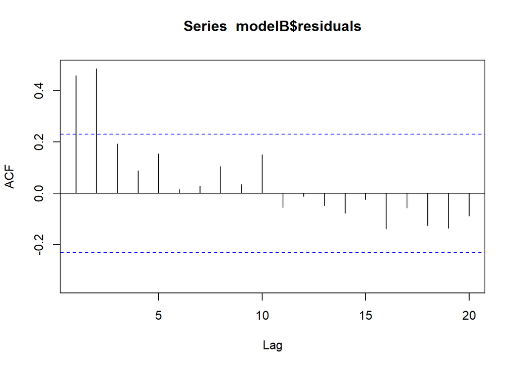

```r
#par(mfrow=c(2,1))
Acf(modelB$residuals,lag.max = 20, plot = TRUE)
```

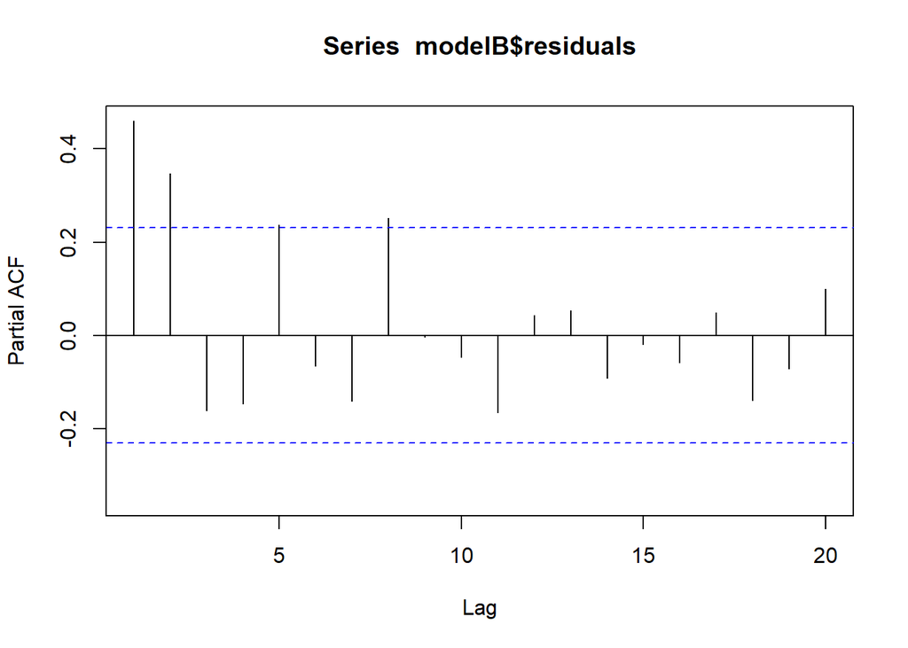

```r
Pacf(modelB$residuals,lag.max = 20, plot = TRUE)
```

#### From the ACF plot, we see the lag at 1 and 2 are significant. This signifies MA(2) model.

#### Similarly, PACF plot is also showing the partial correlation at lags 1 and 2 are significant. This signifies AR(2) model.

#### Assuming the Regression has already removed the Seasonality and Trend leaving the residuals being a stationary time series, the model, we can predict an ARMA(2,2) or ARIMA(2,0,2) as the preferable model to extract the relevant information from the residuals.

### *h. Fit an AR(p) model as you think appropriate from part (g) to the training set residuals and produce the regression coefficients. Was your intuition at part (h) correct?*

```r
# Fit a ARIMA model based on our intuition from the above question.
residualModel <- Arima(modelB$residuals, order = c(2,0,2)) ## (ARIMA(2,0,2) = ARMA(2,2))
residualModel_Forecast <- forecast(residualModel,h=12)
summary(residualModel)
```

```
## Series: modelB$residuals
## ARIMA(2,0,2) with non-zero mean
##
## Coefficients:
##          ar1      ar2     ma1     ma2    mean
##       0.0895  -0.0966  0.2934  0.7722  0.0013
## s.e.  0.1486   0.1778  0.0873  0.1431  0.0315
##
## sigma^2 estimated as 0.01864:  log likelihood=42.96
## AIC=-73.92   AICc=-72.63   BIC=-60.26
##
## Training set error measures:
##                        ME      RMSE       MAE      MPE     MAPE      MASE
## Training set 0.0003670075 0.1317171 0.1060178 4027.564 4574.364 0.5535896
##                     ACF1
## Training set 0.003910029
```

```r
# Fit an auto ARIMA model
auto_ResidualModel <- auto.arima(modelB$residuals)
auto_ResidualModel_Forecast <- forecast(auto_ResidualModel,h=12)
summary(auto_ResidualModel)
```

```
## Series: modelB$residuals
## ARIMA(2,0,0) with zero mean
##
## Coefficients:
##          ar1     ar2
##       0.3072  0.3687
## s.e.  0.1090  0.1102
##
## sigma^2 estimated as 0.02021:  log likelihood=39.03
## AIC=-72.05   AICc=-71.7   BIC=-65.22
##
## Training set error measures:
##                       ME      RMSE       MAE      MPE     MAPE      MASE
## Training set 0.003770241 0.1401745 0.1140928 867.9053 1256.983 0.5957543
##                    ACF1
## Training set 0.02854956
```

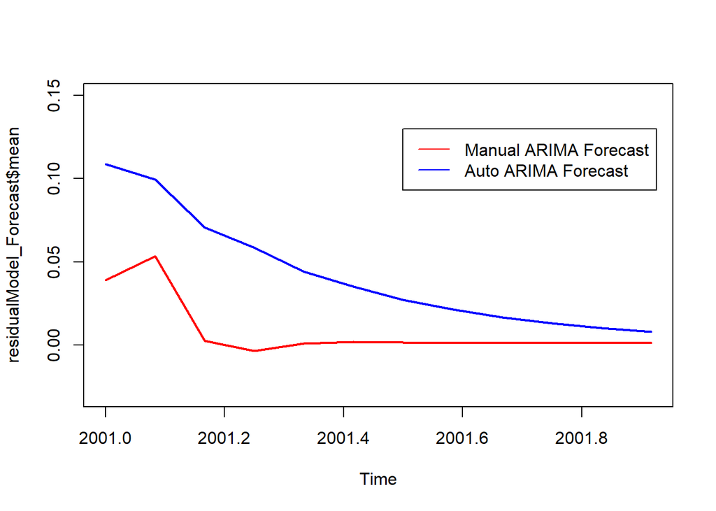

```r
# Compare the Forecasts from auto ARIMA model and manual ARIMA model
plot(residualModel_Forecast$mean, lwd=2, col="red", ylim = c(-0.03, 0.15))
lines(auto_ResidualModel_Forecast$mean, lwd =2, col = "blue")
legend(2001.5,0.13, legend=c("Manual ARIMA Forecast", "Auto ARIMA Forecast"),  col=c("red", "blue"), lty=1:1, cex=1)
```

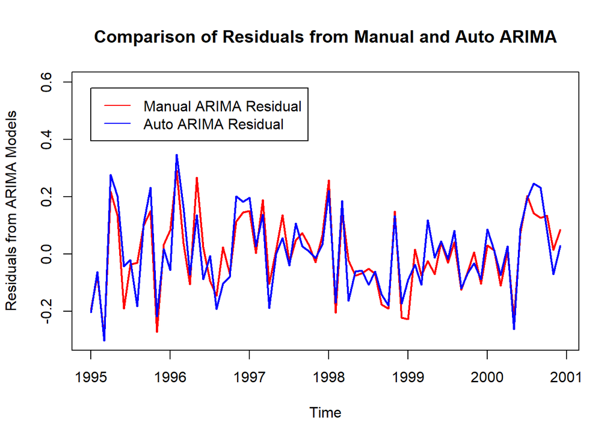

```r
# Compare the Residuals from auto ARIMA model and manual ARIMA model
plot(residualModel$residuals, col = "red", lwd = 2, main = "Comparison of Residuals from Manual and Auto ARIMA", ylab = "Residuals from ARIMA Models", ylim = c(-0.3, 0.6))
lines(auto_ResidualModel$residuals, col = "blue", lwd = 2)
legend(1995,0.58, legend=c("Manual ARIMA Residual", "Auto ARIMA Residual"),  col=c("red", "blue"), lty=1:1, cex=1)
```

### *i. Now, using the best regression model and AR(p) model, forecast the sales in January 2002. Think carefully which data to use for model fitting in this case.*

#### We have already retrained Model B on the entire dataset to forecast the sales in January 2002 on the basis of Trend and Seasonality. We can better our forecast by now using the AR model created above.

```r
residualModel_Retrained <- Arima(modelB_Retrained$residuals, order = c(2,0,2)) ## (ARIMA(2,0,2) = ARMA(2,2))
residualModel_Retrained_Forecast <- forecast(residualModel_Retrained,h=1)
summary(residualModel_Retrained)
```

```
## Series: modelB_Retrained$residuals
## ARIMA(2,0,2) with non-zero mean
##
## Coefficients:
##          ar1     ar2     ma1     ma2    mean
##       0.2002  0.1503  0.1953  0.3472  0.0006
## s.e.  0.2629  0.2284  0.2664  0.2919  0.0350
##
## sigma^2 estimated as 0.01995:  log likelihood=47.47
## AIC=-82.95   AICc=-81.86   BIC=-68.36
##
## Training set error measures:
##                        ME      RMSE       MAE      MPE    MAPE      MASE
## Training set 0.0009884091 0.1369625 0.1108288 79.17213 159.616 0.6343777
##                     ACF1
## Training set -0.01409401
```

```r
residualModel_Retrained_Forecast$mean
```

```
##             Jan
## 2002 0.05264667
```